# Alien Planet

Ever since reading Yuval Noah Harari's 'Sapiens', I had been toying with the idea of creating a simulated world which would explore migrations and population growth. The inhabitants of our world will be randomly allocated within their environment and allowed to move in any direction by one unit, with the exception of inaccessible terrain (which has also been randomly generated). For some reason, I had decided that the inhabitants are actually aliens experiencing the cradle of their existence, trying to make sense of their surroundings. Although the aliens have not been endowed with much complexity, I have granted them the ability to effectively do three things:

- They can migrate.
- They can reproduce.
- They can eliminate eachother.

That being said, there are certain rules to their activities. Reproduction can only take place between males and females and seemingly, only the males attack eachother (as I am writing this, I wonder how ridiculous this all sounds and yet...) The initial conditions of our simulated world may be modulated but for this particular set-up, I have chosen a 100-year span to explore the variations in experience our alien population may come to face.

```
Simulation 1 - The final population is 3 male(s) and 4 female(s).
```

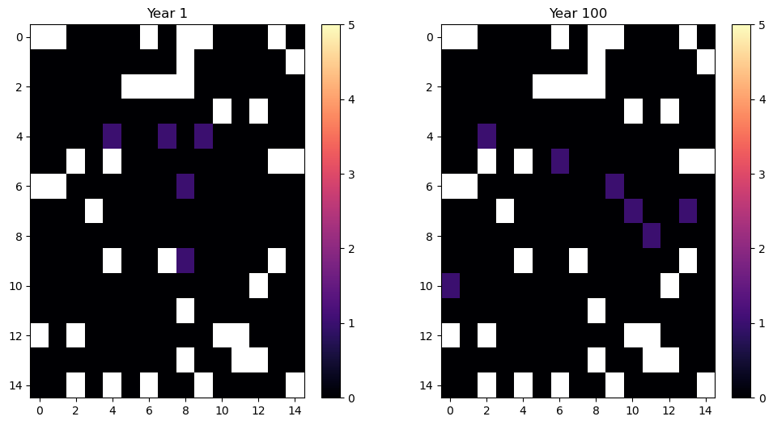

```
Simulation 2 - The final population is 36 male(s) and 44 female(s).
```

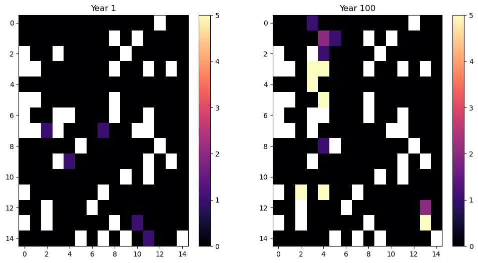

```
Abort: population overload!
Simulation 3 - The final population is 576 male(s) and 646 female(s).
```

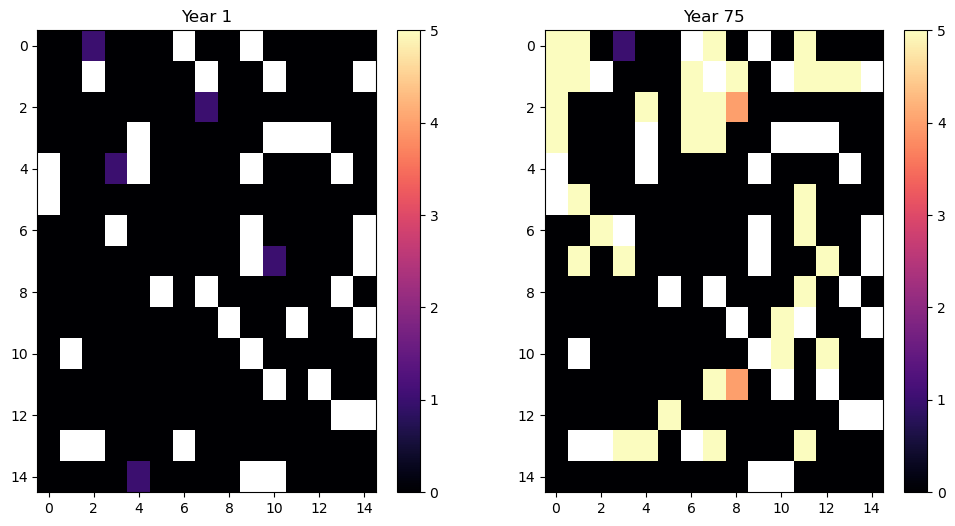

```python
import numpy as np
import copy
import matplotlib.pyplot as plt
from matplotlib.ticker import MaxNLocator

for sim in range(0, 3):
    # Create n x n grid with randomised inhabitable zones
    n = 15
    grid = np.random.uniform(low=0, high=5, size=(n,n))
    grid = np.where(grid < 1, np.nan, 0)

    # Create p initial lifeforms which are randomly allocated on the grid
    p = 5
    initial_coordinates = list()

    for _ in range(0, p):
        x = np.random.randint(0, n)
        y = np.random.randint(0, n)
        initial_coordinates.append([x,y])

    for coordinate in initial_coordinates:
        grid[coordinate[0]][coordinate[1]] = 1

    # Class for floopy aliens
    class floopy():
        def __init__(self, initial_coordinates, grid):
            self.coordinates = initial_coordinates
            self.grid = grid
            self.gender =  np.random.choice(['Male', 'Female'])

        def migrate(self):
            dx = np.random.randint(-1,2)
            dy = np.random.randint(-1,2)
            if self.coordinates[0] + dx < len(grid) - 1 and self.coordinates[0] + dx >= 0:
                if self.coordinates[1] + dy < len(grid) - 1 and self.coordinates[1] + dy >= 0:
                    if not np.isnan(grid[self.coordinates[0] + dx][self.coordinates[1] + dy]):
                        self.coordinates[0] = self.coordinates[0] + dx
                        self.coordinates[1] = self.coordinates[1] + dy
            return self.coordinates

    # Initialise population
    population = []

    for i in range(0, p):
        population.append(floopy(initial_coordinates[i], grid))

    def show_grid(array, iteration, ax):
        ax.imshow(array, cmap='magma', interpolation='nearest', aspect='auto', vmin=0, vmax=5)
        cbar = ax.figure.colorbar(ax.imshow(array, cmap='magma', interpolation='nearest', aspect='auto', vmin=0, vmax=5))
        cbar.ax.yaxis.set_major_locator(MaxNLocator(integer=True))
        ax.set_title(f'Year {iteration+1}')

    fig, (ax1, ax2) = plt.subplots(1, 2, figsize=(12, 6))
    show_grid(grid, 0, ax1)

    #  Run simulation
    for iteration in range(0, 100):
        if len(population) > 1000:
            print("Abort: population overload!")
            break
        for i in range (0, p):
            try:
                old_coordinates = copy.deepcopy(population[i].coordinates)
                new_coordinates = population[i].migrate()
                grid[old_coordinates[0]][old_coordinates[1]] = grid[old_coordinates[0]][old_coordinates[1]] - 1
                grid[new_coordinates[0]][new_coordinates[1]] = grid[new_coordinates[0]][new_coordinates[1]] + 1
                if grid[new_coordinates[0]][new_coordinates[1]] > 1:
                    intersecting_floopies = [(index, obj) for index, obj in enumerate(population) if obj.coordinates == new_coordinates]
                    if intersecting_floopies[0][1].gender != intersecting_floopies[1][1].gender:
                        grid[new_coordinates[0]][new_coordinates[1]] = grid[new_coordinates[0]][new_coordinates[1]] + 1
                        population.append(floopy(new_coordinates, grid))
                        p = p + 1
                        #print("A floopy has been born!")
                    else:
                        if intersecting_floopies[0][1].gender == 'Male':
                            grid[new_coordinates[0]][new_coordinates[1]] = grid[new_coordinates[0]][new_coordinates[1]] - 1
                            population.pop(np.random.choice([intersecting_floopies[0][0], intersecting_floopies[1][0]]))
                            p = p - 1
                            #print("A floopy has died!")
            except:
                continue

    # Show final grid
    male_population = len([obj for obj in population if obj.gender == 'Male'])
    female_population = len([obj for obj in population if obj.gender == 'Female'])
    show_grid(grid, iteration, ax2)
    print("Simulation", sim+1, "- The final population is", male_population, "male(s) and", female_population, "female(s).")
    plt.show()
```